# Dodgers Report

Alkım Ege Akarsu | 21901461

16.03.2024

Import necessary libraries:

```r
library(magrittr)
library(tidyverse)
library(car)
library(knitr)
library(kableExtra)
```

```r
library(pander)
library(RSQLite)
library(corrplot)
```

# Data Overview

Retrieve data from the SQLite database:

```r
con <-dbConnect(SQLite(), "./data/dodgers.sqlite")
# Import db into r data frame
db <- dbGetQuery(con, "SELECT * from events;")
dbDisconnect(con)
```

Get some example data points:

```r
head(db)
```

```
##   month day attend day_of_week opponent temp  skies day_night cap shirt
## 1   APR  10  56000     Tuesday  Pirates   67  Clear       Day  NO    NO
## 2   APR  11  29729   Wednesday  Pirates   58 Cloudy     Night  NO    NO
## 3   APR  12  28328    Thursday  Pirates   57 Cloudy     Night  NO    NO
## 4   APR  13  31601      Friday   Padres   54 Cloudy     Night  NO    NO
## 5   APR  14  46549    Saturday   Padres   57 Cloudy     Night  NO    NO
## 6   APR  15  38359      Sunday   Padres   65  Clear       Day  NO    NO
##   fireworks bobblehead
## 1        NO         NO
## 2        NO         NO
## 3        NO         NO
## 4       YES         NO
## 5        NO         NO
## 6        NO         NO
```

Convert categorical variables into factors for ease of use:

```r
db <- db %>%
  mutate(month = factor(month, levels = c("APR", "MAY", "JUN", "JUL", "AUG", "SEP", "OCT")),
         day_of_week = factor(day_of_week, levels = c("Monday", "Tuesday", "Wednesday", "Thursday", "Friday", "Saturday", "Sunday")),
         temp = (temp - 32) * 5 / 9) %>% # in celsius
  mutate(across(where(is.character), factor))
```

List all columns and possible values:

```r
columns <- colnames(db)
for (column in columns) {
  unique_values <- unique(db[[column]])
  print(paste("Possible values for ", column, ": ", toString(unique_values)))
}
```

```
## [1] "Possible values for  month :  APR, MAY, JUN, JUL, AUG, SEP, OCT"
## [1] "Possible values for  day :  10, 11, 12, 13, 14, 15, 23, 24, 25, 27, 28, 29, 7, 8, 9, 18, 19, 20, 26, 30, 31, 16, 17, 1, 2, 3, 4, 5, 6, 21, 22"
## [1] "Possible values for  attend :  56000, 29729, 28328, 31601, 46549, 38359, 26376, 44014, 26345, 44807, 54242, 48753, 43713, 32799, 33993, 35591, 33735, 49124, 24312, 47077, 40906, 39383, 44005, 36283, 36561, 33306, 38016, 51137, 25509, 26773, 50559, 55279, 43494, 40432, 45210, 53504, 49006, 49…
## [1] "Possible values for  day_of_week :  Tuesday, Wednesday, Thursday, Friday, Saturday, Sunday, Monday"
## [1] "Possible values for  opponent :  Pirates, Padres, Braves, Nationals, Giants, Rockies, Snakes, Cardinals, Astros, Brewers, Angels, White Sox, Mets, Reds, Phillies, Cubs, Marlins"
## [1] "Possible values for  temp :  19.4444444444444, 14.4444444444444, 13.8888888888889, 12.2222222222222, 18.3333333333333, 15.5555555555556, 17.2222222222222, 17.7777777777778, 18.8888888888889, 21.6666666666667, 23.3333333333333, 23.8888888888889, 21.1111111111111, 25, 15, 16.1111111111111, 22.…
## [1] "Possible values for  skies :  Clear, Cloudy"
## [1] "Possible values for  day_night :  Day, Night"
## [1] "Possible values for  cap :  NO, YES"
## [1] "Possible values for  shirt :  NO, YES"
## [1] "Possible values for  fireworks :  NO, YES"
## [1] "Possible values for  bobblehead :  NO, YES"
```

Get the summary of data:

```r
summary(db)
```

```
##  month         day            attend         day_of_week      opponent
##  APR:12   Min.   : 1.00   Min.   :24312   Monday   :12   Giants   : 9
##  MAY:18   1st Qu.: 8.00   1st Qu.:34493   Tuesday  :13   Padres   : 9
##  JUN: 9   Median :15.00   Median :40284   Wednesday:12   Rockies  : 9
##  JUL:12   Mean   :16.14   Mean   :41040   Thursday : 5   Snakes   : 9
##  AUG:15   3rd Qu.:25.00   3rd Qu.:46588   Friday   :13   Cardinals: 7
##  SEP:12   Max.   :31.00   Max.   :56000   Saturday :13   Brewers  : 4
##  OCT: 3                                   Sunday   :13   (Other)  :34
##       temp          skies    day_night   cap     shirt    fireworks bobblehead
##  Min.   :12.22   Clear :62   Day  :15   NO :79   NO :78   NO :67    NO :70
##  1st Qu.:19.44   Cloudy:19   Night:66   YES: 2   YES: 3   YES:14    YES:11
##  Median :22.78
##  Mean   :22.86
##  3rd Qu.:26.11
##  Max.   :35.00
##
```

# Chi Squared Tests

Check for **distribution uniformity** between **categorical** explanatory variables and the response variable (attendance). If the mean attendance between the categories in an explanatory variable is close to each other (attendance is uniformly distributed between the categories), the p-value is large and we say that the explanatory variable is not an important predictor of attendance. Since day and temperature are not categorical variables, they cannot be tested this way.

- **Month** and attendance:

```r
db %>%
  group_by(month) %>%
  summarize(avgattend = mean(attend)) %>%
  pull(avgattend) %>% chisq.test()
```

```
##
##  Chi-squared test for given probabilities
##
## data:  .
## X-squared = 2377.3, df = 6, p-value < 2.2e-16
```

- **Day of week** and attendance:

```r
db %>%
  group_by(day_of_week) %>%
  summarize(avgattend = mean(attend)) %>%
  pull(avgattend) %>% chisq.test()
```

```
##
##  Chi-squared test for given probabilities
##
## data:  .
## X-squared = 2457.3, df = 6, p-value < 2.2e-16
```

- **Opponent** and attendance:

```r
db %>%
  group_by(opponent) %>%
  summarize(avgattend = mean(attend)) %>%
  pull(avgattend) %>% chisq.test()
```

```
##
##  Chi-squared test for given probabilities
##
## data:  .
## X-squared = 9981.5, df = 16, p-value < 2.2e-16
```

- **Skies** and attendance:

```r
db %>%
  group_by(skies) %>%
  summarize(avgattend = mean(attend)) %>%
  pull(avgattend) %>% chisq.test()
```

```
##
##  Chi-squared test for given probabilities
##
## data:  .
## X-squared = 107.19, df = 1, p-value < 2.2e-16
```

- **Day or night** and attendance:

```r
db %>%
  group_by(day_night) %>%
  summarize(avgattend = mean(attend)) %>%
  pull(avgattend) %>% chisq.test()
```

```
##
##  Chi-squared test for given probabilities
##
## data:  .
## X-squared = 10.337, df = 1, p-value = 0.001304
```

- **Cap** and attendance:

```r
db %>%
  group_by(cap) %>%
  summarize(avgattend = mean(attend)) %>%
  pull(avgattend) %>% chisq.test()
```

```
##
##  Chi-squared test for given probabilities
##
## data:  .
## X-squared = 107.72, df = 1, p-value < 2.2e-16
```

- **Shirt** and attendance:

```r
db %>%
  group_by(shirt) %>%
  summarize(avgattend = mean(attend)) %>%
  pull(avgattend) %>% chisq.test()
```

```
##
##  Chi-squared test for given probabilities
##
## data:  .
## X-squared = 387.14, df = 1, p-value < 2.2e-16
```

- **Fireworks** and attendance:

```r
db %>%
  group_by(fireworks) %>%
  summarize(avgattend = mean(attend)) %>%
  pull(avgattend) %>% chisq.test()
```

```
##
##  Chi-squared test for given probabilities
##
## data:  .
## X-squared = 0.025411, df = 1, p-value = 0.8733
```

- **Bobblehead** and attendance:

```r
db %>%
  group_by(bobblehead) %>%
  summarize(avgattend = mean(attend)) %>%
  pull(avgattend) %>% chisq.test()
```

```
##
##  Chi-squared test for given probabilities
##
## data:  .
## X-squared = 2125.9, df = 1, p-value < 2.2e-16
```

Out of all categorical predictors, only **fireworks** has p-value larger than 0.05. This means that on average, days that did and didn’t have fireworks had very **similar** attendance.

# Linear Regression

Train a linear regression model using all available variables. Regress attendance on month, day, day_of_week, opponent, temp, skies, day_night, cap, shirt, fireworks, bobblehead.

```r
linear_model_large <- lm(attend ~ month + day + day_of_week + opponent + temp + skies + day_night + cap + shirt + fireworks + bobblehead, db)
Anova(linear_model_large)
```

```
## Anova Table (Type II tests)
##
## Response: attend
##                 Sum Sq Df F value   Pr(>F)
## month        107253092  6  0.5000 0.804880
## day           31985882  1  0.8947 0.349369
## day_of_week  622226954  6  2.9008 0.018021 *
## opponent     482404341 16  0.8434 0.632580
## temp             48765  1  0.0014 0.970705
## skies            73327  1  0.0021 0.964082
## day_night     34516507  1  0.9655 0.331177
## cap           44252037  1  1.2378 0.271933
## shirt          1648173  1  0.0461 0.830981
## fireworks    208621672  1  5.8356 0.019925 *
## bobblehead   305478664  1  8.5449 0.005455 **
## Residuals   1572994766 44
## ---
## Signif. codes:  0 '***' 0.001 '**' 0.01 '*' 0.05 '.' 0.1 ' ' 1
```

According to the Type 2 Analysis of Variance (ANOVA) report, only **day of the week**, **fireworks**, and **bobblehead** have statistically significant effect on attendance (p-value smaller than 0.05).

```r
summary(linear_model_large)
```

```
##
## Call:
## lm(formula = attend ~ month + day + day_of_week + opponent +
##     temp + skies + day_night + cap + shirt + fireworks + bobblehead,
##     data = db)
##
## Residuals:
##     Min      1Q  Median      3Q     Max
## -9300.2 -3166.2   -60.2  1387.1 12599.9
##
## Coefficients:
##                       Estimate Std. Error t value Pr(>|t|)
## (Intercept)           48472.69   14157.72   3.424  0.00135 **
## monthMAY               4292.17    6171.24   0.696  0.49039
## monthJUN              -3401.85   12098.49  -0.281  0.77989
## monthJUL               4195.67    6228.54   0.674  0.50408
## monthAUG               8003.27    7716.68   1.037  0.30534
## monthSEP               3505.86    7740.31   0.453  0.65282
## monthOCT               5434.11    9589.49   0.567  0.57382
## day                     133.64     141.28   0.946  0.34937
## day_of_weekTuesday     8674.11    2944.00   2.946  0.00513 **
## day_of_weekWednesday     13.24    2765.42   0.005  0.99620
## day_of_weekThursday     525.39    3906.85   0.134  0.89364
## day_of_weekFriday    -18253.57    9216.71  -1.980  0.05392 .
## day_of_weekSaturday    3688.89    3341.26   1.104  0.27558
## day_of_weekSunday       830.09    4819.11   0.172  0.86403
## opponentAstros       -20871.31   14215.14  -1.468  0.14915
## opponentBraves       -18977.73   13742.73  -1.381  0.17428
## opponentBrewers      -22827.23   15163.65  -1.505  0.13937
## opponentCardinals    -12986.02   13157.20  -0.987  0.32904
## opponentCubs         -10795.01   12633.90  -0.854  0.39749
## opponentGiants       -17279.00   13263.05  -1.303  0.19942
## opponentMarlins      -19335.74   13901.01  -1.391  0.17123
## opponentMets          -4492.43    6422.73  -0.699  0.48795
## opponentNationals     -6543.71   13941.96  -0.469  0.64113
## opponentPadres       -11480.11   11321.49  -1.014  0.31612
## opponentPhillies     -13922.32   12598.96  -1.105  0.27515
## opponentPirates      -12835.96   13339.19  -0.962  0.34117
## opponentReds         -16654.40   11914.66  -1.398  0.16918
## opponentRockies      -17348.59   12957.53  -1.339  0.18749
## opponentSnakes       -20268.77   12731.38  -1.592  0.11854
## opponentWhite Sox      -971.86    5734.64  -0.169  0.86620
## temp                     16.35     442.68   0.037  0.97071
## skiesCloudy            -108.12    2387.21  -0.045  0.96408
## day_nightNight        -3520.45    3582.79  -0.983  0.33118
## capYES                -6534.52    5873.33  -1.113  0.27193
## shirtYES                987.69    4600.00   0.215  0.83098
## fireworksYES          20183.54    8355.16   2.416  0.01992 *
## bobbleheadYES          9349.21    3198.32   2.923  0.00545 **
## ---
## Signif. codes:  0 '***' 0.001 '**' 0.01 '*' 0.05 '.' 0.1 ' ' 1
##
## Residual standard error: 5979 on 44 degrees of freedom
## Multiple R-squared:  0.7144, Adjusted R-squared:  0.4808
## F-statistic: 3.057 on 36 and 44 DF,  p-value: 0.0002493
```

Further analysis of the p-values of individual coefficients reveal that day of the week being **Tuesday** has a statistically significant effect on attendance while day of the week being any other day does not.

```r
# linear_model <- lm(attend ~ month + day + day_of_week + opponent + skies + day_night + cap + shirt + fireworks + bobblehead, db)
# Anova(linear_model)

# linear_model <- lm(attend ~ month + day + day_of_week + opponent + day_night + cap + shirt + fireworks + bobblehead, db)
# Anova(linear_model)

# linear_model <- lm(attend ~ month + day + day_of_week + opponent + day_night + cap + fireworks + bobblehead, db)
# Anova(linear_model)

# linear_model <- lm(attend ~ day + day_of_week + opponent + day_night + cap + fireworks + bobblehead, db)
# Anova(linear_model)

# linear_model <- lm(attend ~ day_of_week + opponent + day_night + cap + fireworks + bobblehead, db)
# Anova(linear_model)

# linear_model <- lm(attend ~ day_of_week + opponent + day_night + fireworks + bobblehead, db)
# Anova(linear_model)

linear_model_small <- lm(attend ~ day_of_week + opponent + fireworks + bobblehead, db)
Anova(linear_model_small)
```

```
## Anova Table (Type II tests)
##
## Response: attend
##                 Sum Sq Df F value    Pr(>F)
## day_of_week  654360297  6  3.3600  0.006722 **
## opponent    1033299552 16  1.9897  0.030229 *
## fireworks    314152212  1  9.6786  0.002932 **
## bobblehead   601228289  1 18.5230 6.808e-05 ***
## Residuals   1817678850 56
## ---
## Signif. codes:  0 '***' 0.001 '**' 0.01 '*' 0.05 '.' 0.1 ' ' 1
```

After repeatedly removing the predictor with the largest p-value until only predictors with p-values smaller than 0.05 remain, we are left with **day of the week**, **opponent**, **fireworks**, and **bobblehead**.

```r
summary(linear_model_small)
```

```
##
## Call:
## lm(formula = attend ~ day_of_week + opponent + fireworks + bobblehead,
##     data = db)
##
## Residuals:
##      Min       1Q   Median       3Q      Max
## -10337.3  -3115.4    -15.3   2168.3  12971.1
##
## Coefficients:
##                        Estimate Std. Error t value Pr(>|t|)
## (Intercept)           4.342e+04  3.585e+03  12.112  < 2e-16 ***
## day_of_weekTuesday    7.821e+03  2.591e+03   3.018  0.00383 **
## day_of_weekWednesday  5.561e+02  2.429e+03   0.229  0.81975
## day_of_weekThursday   5.531e+01  3.502e+03   0.016  0.98746
## day_of_weekFriday    -2.133e+04  8.061e+03  -2.646  0.01055 *
## day_of_weekSaturday   2.714e+03  2.899e+03   0.936  0.35327
## day_of_weekSunday     2.732e+03  2.897e+03   0.943  0.34968
## opponentAstros       -1.032e+04  5.162e+03  -1.999  0.05046 .
## opponentBraves       -1.397e+04  4.725e+03  -2.956  0.00455 **
## opponentBrewers      -1.284e+04  4.430e+03  -2.899  0.00533 **
## opponentCardinals    -4.531e+03  4.479e+03  -1.012  0.31598
## opponentCubs         -1.496e+03  5.162e+03  -0.290  0.77299
## opponentGiants       -8.104e+03  3.838e+03  -2.112  0.03920 *
## opponentMarlins      -5.038e+03  5.162e+03  -0.976  0.33332
## opponentMets         -9.075e+02  4.863e+03  -0.187  0.85265
## opponentNationals    -7.543e-01  5.173e+03   0.000  0.99988
## opponentPadres       -4.969e+03  4.081e+03  -1.218  0.22846
## opponentPhillies     -4.315e+03  4.725e+03  -0.913  0.36501
## opponentPirates      -8.212e+03  4.913e+03  -1.672  0.10019
## opponentReds         -1.314e+04  5.344e+03  -2.459  0.01705 *
## opponentRockies      -7.430e+03  4.081e+03  -1.821  0.07399 .
## opponentSnakes       -1.024e+04  3.912e+03  -2.617  0.01139 *
## opponentWhite Sox     6.790e+02  5.162e+03   0.132  0.89582
## fireworksYES          2.274e+04  7.308e+03   3.111  0.00293 **
## bobbleheadYES         1.070e+04  2.485e+03   4.304 6.81e-05 ***
## ---
## Signif. codes:  0 '***' 0.001 '**' 0.01 '*' 0.05 '.' 0.1 ' ' 1
##
## Residual standard error: 5697 on 56 degrees of freedom
## Multiple R-squared:   0.67,  Adjusted R-squared:  0.5286
## F-statistic: 4.737 on 24 and 56 DF,  p-value: 8.262e-07
```

```r
anova(linear_model_large, linear_model_small)
```

```
## Analysis of Variance Table
##
## Model 1: attend ~ month + day + day_of_week + opponent + temp + skies +
##     day_night + cap + shirt + fireworks + bobblehead
## Model 2: attend ~ day_of_week + opponent + fireworks + bobblehead
##   Res.Df        RSS  Df  Sum of Sq      F Pr(>F)
## 1     44 1572994766
## 2     56 1817678850 -12 -244684085 0.5704 0.8537
```

According to the ANOVA report including the large and small linear regression models, the larger model is not significantly better than the smaller model. The p-value of 0.85 is way larger than the 0.05 threshold, signifying that the larger model is not meaningfully different from the smaller model.

### The Fireworks Issue

Fireworks was the only categorical predictor to have a chi-squared test of uniformity p-value of larger than 0.05. So how did a predictor that was deemed unimportant by the chi-squared test is determined to have a statistically significant effect on attendance by linear regression coefficient p-values and ANOVA reports?

```r
linear_model <- lm(attend ~ fireworks, db)
Anova(linear_model)
```

```
## Anova Table (Type II tests)
##
## Response: attend
##               Sum Sq Df F value Pr(>F)
## fireworks      24162  1   3e-04 0.9852
## Residuals 5507908726 79
```

```r
summary(linear_model)
```

```
##
## Call:
## lm(formula = attend ~ fireworks, data = db)
##
## Residuals:
##      Min       1Q   Median       3Q      Max
## -16720.2  -6539.2   -748.2   5555.8  14967.8
##
## Coefficients:
##              Estimate Std. Error t value Pr(>|t|)
## (Intercept)  41032.18    1020.10  40.224   <2e-16 ***
## fireworksYES    45.68    2453.70   0.019    0.985
## ---
## Signif. codes:  0 '***' 0.001 '**' 0.01 '*' 0.05 '.' 0.1 ' ' 1
##
## Residual standard error: 8350 on 79 degrees of freedom
## Multiple R-squared:  4.387e-06,  Adjusted R-squared:  -0.01265
## F-statistic: 0.0003466 on 1 and 79 DF,  p-value: 0.9852
```

```r
anova(linear_model, linear_model_small)
```

```
## Analysis of Variance Table
##
## Model 1: attend ~ fireworks
## Model 2: attend ~ day_of_week + opponent + fireworks + bobblehead
##   Res.Df        RSS Df  Sum of Sq      F    Pr(>F)
## 1     79 5507908726
## 2     56 1817678850 23 3690229875 4.9431 5.351e-07 ***
## ---
## Signif. codes:  0 '***' 0.001 '**' 0.01 '*' 0.05 '.' 0.1 ' ' 1
```

A linear regression model using only fireworks as a predictor has a very large p-value in the Type 2 ANOVA test and coefficients. The small model found in the previous section is also much better than the fireworks only model (Type 1 ANOVA p-value smaller than 0.05). These results tell us that fireworks alone is not a good predictor of attendance.

However, **when paired with other predictors**, fireworks becomes a statistically significant predictor of attendance. Because of this reason, while the situation detailed above may seem contradictory at first, further investigation reveals that there is no contradiction.

```r
linear_model <- lm(attend ~ fireworks + bobblehead, db)
Anova(linear_model)
```

```
## Anova Table (Type II tests)
##
## Response: attend
##                Sum Sq Df F value    Pr(>F)
## fireworks    65858150  1  1.4361    0.2344
## bobblehead 1930829724  1 42.1027 7.273e-09 ***
## Residuals  3577079001 78
## ---
## Signif. codes:  0 '***' 0.001 '**' 0.01 '*' 0.05 '.' 0.1 ' ' 1
```

```r
linear_model <- lm(attend ~ opponent + fireworks, db)
Anova(linear_model)
```

```
## Anova Table (Type II tests)
##
## Response: attend
##               Sum Sq Df F value Pr(>F)
## opponent  1433393722 16  1.3852 0.1784
## fireworks   23660866  1  0.3658 0.5475
## Residuals 4074515003 63
```

```r
linear_model <- lm(attend ~ day_of_week + fireworks, db)
Anova(linear_model)
```

```
## Anova Table (Type II tests)
##
## Response: attend
##                 Sum Sq Df F value    Pr(>F)
## day_of_week 1534939312  6  4.7005 0.0004266 ***
## fireworks    278743524  1  5.1217 0.0266029 *
## Residuals   3972969414 73
## ---
## Signif. codes:  0 '***' 0.001 '**' 0.01 '*' 0.05 '.' 0.1 ' ' 1
```

```r
summary(linear_model)
```

```
##
## Call:
## lm(formula = attend ~ day_of_week + fireworks, data = db)
##
## Residuals:
##      Min       1Q   Median       3Q      Max
## -14942.2  -3909.8   -311.9   4041.0  15593.3
##
## Coefficients:
##                      Estimate Std. Error t value Pr(>|t|)
## (Intercept)             34966       2130  16.419  < 2e-16 ***
## day_of_weekTuesday      12776       2953   4.326 4.74e-05 ***
## day_of_weekWednesday     1166       3079   0.379  0.70597
## day_of_weekThursday      5442       3927   1.386  0.17004
## day_of_weekFriday      -12287       8252  -1.489  0.14081
## day_of_weekSaturday      8107       2953   2.745  0.00761 **
## day_of_weekSunday        7303       2953   2.473  0.01573 *
## fireworksYES            17438       7705   2.263  0.02660 *
## ---
## Signif. codes:  0 '***' 0.001 '**' 0.01 '*' 0.05 '.' 0.1 ' ' 1
##
## Residual standard error: 7377 on 73 degrees of freedom
## Multiple R-squared:  0.2787, Adjusted R-squared:  0.2095
## F-statistic: 4.029 on 7 and 73 DF,  p-value: 0.000881
```

**Fireworks** predictor seems to gain significance when combined with the **day of the week** predictor.

### Multicollinearity

**Variance inflation factor** (**VIF**) is a metric that can be used to test the predictors of a model for multicollinearity. Multicollinearity occurs when several predictors of a model are correlated. The larger the VIF value of a predictor, the easier it is to estimate that predictor using other predictors.

```r
vif(linear_model_large)
```

```
##                     GVIF Df GVIF^(1/(2*Df))
## month       1.567817e+04  6        2.236701
## day         4.121367e+00  1        2.030115
## day_of_week 6.517351e+02  6        1.715955
## opponent    1.532773e+05 16        1.452266
## temp        9.363005e+00  1        3.059903
## skies       2.318287e+00  1        1.522592
## day_night   4.388525e+00  1        2.094881
## cap         1.882203e+00  1        1.371934
## shirt       1.709904e+00  1        1.307633
## fireworks   2.261274e+01  1        4.755285
## bobblehead  2.720038e+00  1        1.649254
```

The corrected generalized variance inflation factor is largest for the fireworks predictor. It might be a good idea to remove fireworks first, then apply the same procedure as above to construct our linear model.

```r
# linear_model_small_2 <- lm(attend ~ month + day + day_of_week + opponent + temp + skies + day_night + cap + shirt + bobblehead, db)
# Anova(linear_model_small_2)

# linear_model_small_2 <- lm(attend ~ month + day + day_of_week + opponent + skies + day_night + cap + shirt + bobblehead, db)
# Anova(linear_model_small_2)

# linear_model_small_2 <- lm(attend ~ day + day_of_week + opponent + skies + day_night + cap + shirt + bobblehead, db)
# Anova(linear_model_small_2)

# linear_model_small_2 <- lm(attend ~ day + day_of_week + opponent + skies + day_night + cap + bobblehead, db)
# Anova(linear_model_small_2)

# linear_model_small_2 <- lm(attend ~ day + day_of_week + opponent + skies + cap + bobblehead, db)
# Anova(linear_model_small_2)

# linear_model_small_2 <- lm(attend ~ day + day_of_week + opponent + cap + bobblehead, db)
# Anova(linear_model_small_2)

linear_model_small_2 <- lm(attend ~ day_of_week + opponent + cap + bobblehead, db)
Anova(linear_model_small_2)
```

```
## Anova Table (Type II tests)
##
## Response: attend
##                 Sum Sq Df F value    Pr(>F)
## day_of_week  435874289  6  2.0459 0.0745070 .
## opponent    1115415046 16  1.9633 0.0328229 *
## cap          143416300  1  4.0391 0.0492863 *
## bobblehead   589401793  1 16.5994 0.0001469 ***
## Residuals   1988414763 56
## ---
## Signif. codes:  0 '***' 0.001 '**' 0.01 '*' 0.05 '.' 0.1 ' ' 1
```

After repeatedly removing the predictor with the largest p-value until only predictors with p-values smaller than 0.05 remain (removal of day_of_week made everything worse), we are left with **day of the week**, **opponent**, **cap**, and **bobblehead**.

```r
summary(linear_model_small_2)
```

```
##
## Call:
## lm(formula = attend ~ day_of_week + opponent + cap + bobblehead,
##     data = db)
##
## Residuals:
##      Min       1Q   Median       3Q      Max
## -10341.4  -3665.0   -537.3   2303.4  13310.7
##
## Coefficients:
##                       Estimate Std. Error t value Pr(>|t|)
## (Intercept)           42473.05    3742.05  11.350 3.81e-16 ***
## day_of_weekTuesday     8784.26    2771.91   3.169 0.002479 **
## day_of_weekWednesday   2490.23    2458.80   1.013 0.315521
## day_of_weekThursday    1067.37    3669.85   0.291 0.772242
## day_of_weekFriday      2041.18    3033.14   0.673 0.503741
## day_of_weekSaturday    3360.51    3026.19   1.110 0.271540
## day_of_weekSunday      4211.89    3053.12   1.380 0.173213
## opponentAstros       -10294.24    5399.20  -1.907 0.061705 .
## opponentBraves       -13986.21    4942.59  -2.830 0.006456 **
## opponentBrewers      -12859.35    4633.08  -2.776 0.007478 **
## opponentCardinals     -4518.98    4684.40  -0.965 0.338849
## opponentCubs           2156.62    5675.25   0.380 0.705380
## opponentGiants        -8116.92    4014.69  -2.022 0.047985 *
## opponentMarlins       -5012.24    5399.20  -0.928 0.357220
## opponentMets           -876.22    5086.91  -0.172 0.863863
## opponentNationals        43.64    5410.99   0.008 0.993594
## opponentPadres        -4951.94    4268.08  -1.160 0.250879
## opponentPhillies      -4334.21    4942.59  -0.877 0.384281
## opponentPirates       -8568.00    5141.80  -1.666 0.101229
## opponentReds          -1954.68    5225.52  -0.374 0.709769
## opponentRockies       -7412.94    4268.08  -1.737 0.087915 .
## opponentSnakes       -10119.25    4091.33  -2.473 0.016445 *
## opponentWhite Sox       704.42    5399.20   0.130 0.896664
## capYES               -10882.60    5414.93  -2.010 0.049286 *
## bobbleheadYES         10638.36    2611.13   4.074 0.000147 ***
## ---
## Signif. codes:  0 '***' 0.001 '**' 0.01 '*' 0.05 '.' 0.1 ' ' 1
##
## Residual standard error: 5959 on 56 degrees of freedom
## Multiple R-squared:  0.639,  Adjusted R-squared:  0.4843
## F-statistic:  4.13 on 24 and 56 DF,  p-value: 6.258e-06
```

Further analysis of the p-values of individual coefficients reveal that day of the week being **Tuesday**, and opponent being **Braves**, **Brewers**, **Giants**, or **Snakes** have a statistically significant effect on attendance while other days of the week and opponents do not.

```r
anova(linear_model_small_2, linear_model_small)
```

```
## Analysis of Variance Table
##
## Model 1: attend ~ day_of_week + opponent + cap + bobblehead
## Model 2: attend ~ day_of_week + opponent + fireworks + bobblehead
##   Res.Df        RSS Df Sum of Sq F Pr(>F)
## 1     56 1988414763
## 2     56 1817678850  0 170735913
```

```r
anova(linear_model_small_2, linear_model_large)
```

```
## Analysis of Variance Table
##
## Model 1: attend ~ day_of_week + opponent + cap + bobblehead
## Model 2: attend ~ month + day + day_of_week + opponent + temp + skies +
##     day_night + cap + shirt + fireworks + bobblehead
##   Res.Df        RSS Df Sum of Sq      F Pr(>F)
## 1     56 1988414763
## 2     44 1572994766 12 415419997 0.9683 0.4923
```

According to the ANOVA report including the large and the second small linear regression models, the larger model is not significantly better than the second smaller model. The p-value of 0.49 is way larger than the 0.05 threshold, signifying that the larger model is not meaningfully different from the smaller model.

### Linear Regression Conclusion

Comparing the performance of the three linear models:

|  | Large | Small 1 | Small 2 |
| --- | --- | --- | --- |
| **Multiple R-squared** | 0.7144 | 0.67 | 0.639 |
| **Adjusted R-squared** | 0.4808 | 0.5286 | 0.4843 |

# Nonlinear Effects

Examine the temperature predictor:

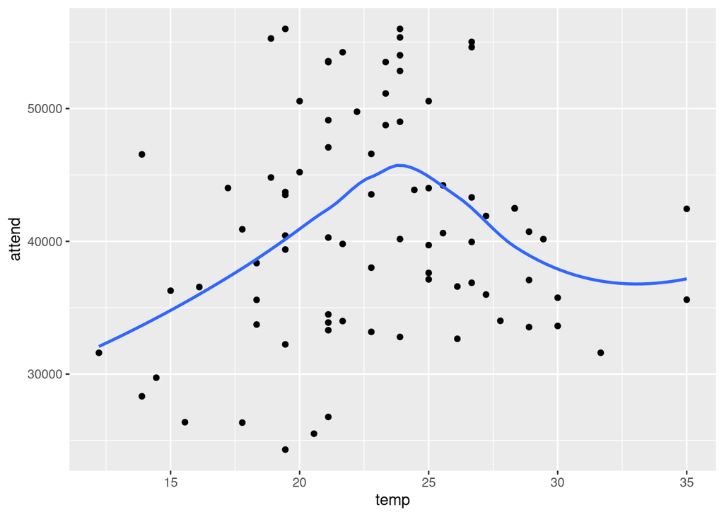

```r
db %>%
  ggplot(aes(temp, attend)) +
  geom_point() +
  geom_smooth(se=FALSE)
```

Temperature can be seen to have a highly nonlinear effect on attendance. Mean attendance rises until and peaks at around **24°C**, then declines.

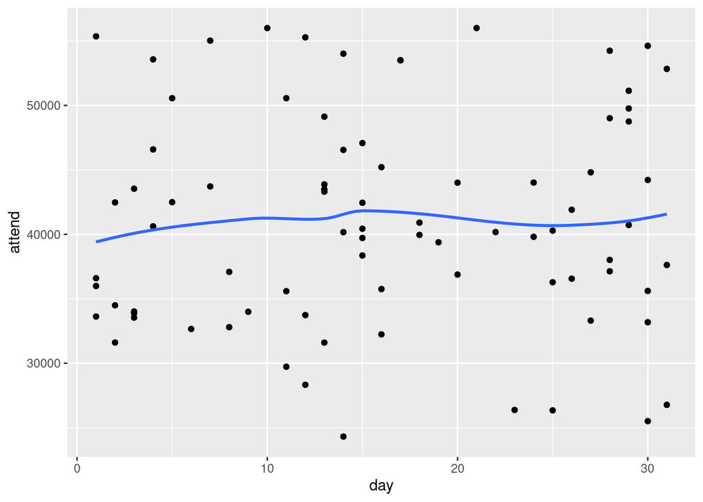

```r
db %>%
  ggplot(aes(day, attend)) +
  geom_point() +
  geom_smooth(se=FALSE)
```

On the contrary, day of the month does not seem to have an obvious pattern.

# Conclusion

One thing is clear from all models: **running a bobblehead promotion has a statistically significant and positive effect on attendance**.

```r
coef(linear_model_large)["bobbleheadYES"]
```

```
## bobbleheadYES
##      9349.214
```

```r
confint(linear_model_large, "bobbleheadYES")
```

```
##                  2.5 %   97.5 %
## bobbleheadYES 2903.423 15795.01
```

```r
coef(linear_model_small)["bobbleheadYES"]
```

```
## bobbleheadYES
##      10695.34
```

```r
confint(linear_model_small, "bobbleheadYES")
```

```
##                 2.5 %   97.5 %
## bobbleheadYES 5717.14 15673.55
```

```r
coef(linear_model_small_2)["bobbleheadYES"]
```

```
## bobbleheadYES
##      10638.36
```

```r
confint(linear_model_small_2, "bobbleheadYES")
```

```
##                  2.5 %   97.5 %
## bobbleheadYES 5407.637 15869.08
```

Comparing the bobblehead predictions of the three models:

|  | Large | Small 1 | Small 2 |
| --- | --- | --- | --- |
| **Coefficient** | 9349.214 | 10695.34 | 10638.36 |
| **2.5% Bound** | 2903.423 | 5717.14 | 5407.637 |
| **97.5% Bound** | 15795.01 | 15673.55 | 15869.08 |

The mean prediction for how many attendees running a bobblehead promotion alone can bring is 10227.638 by the three models.

Temperature seems to have a nonlinear effect on attendance, peaking at 24°C.

I would be very cautious when making any statements about predictors fireworks or caps. Fireworks seems to have a uniform distribution and have a multicollinearity issue. Caps is only statistically significant in one model and has the coefficient -10882.60. Running a promotion on baseball caps being detrimental to attendance does not make real world sense. Overall, the dataset for the models to be trained on is limited. Collection of more data would certainly provide higher confidence when coming to conclusions.

Finally, it is very important to remember **correlation does not equal causation**. The linear models fit in this assignment measure only correlation. The effects of a predictor on the response can be reversed or be caused by a totally separate, third variable.